# R Notebook

一、研究课题 泰坦尼克号的沉没是历史上最著名的沉船事故之⼀。1912年4⽉15⽇，在处⼥航中，被认为“永不沉没”的皇家邮轮泰坦尼克号与冰⼭相撞后沉没。不幸的是，船上没有⾜够的救⽣艇容纳所有⼈，导致2224名乘客和船员中的1502⼈死亡。虽然⽣存有⼀些运⽓因素，但似乎有些群体⽐其他群体更有可能⽣存下来。请使⽤乘客数据（包括姓名、年龄、性别、社会经济阶层等）建⽴⼀个预测模型，尝试思考和回答以下问题：“什么样的⼈更有可能存活下来？”。

二、确定模型 对于这个问题，由于需要预测是否存活（Survived），是一个典型的二元分类问题。因此，可以使用各种二元分类模型来进行分析。可以使用广义线性回归中的逻辑回归模型。

三、原始数据分析 在对数据进行预处理前，可以先对原数据进行一系列分析，首先导入csv文件：

```r
# 将数据导入数据框
titanic_data <- read.csv("titanic.csv", stringsAsFactors = FALSE)
# 查看数据框的结构
str(titanic_data)
```

```
'data.frame':   891 obs. of  12 variables:
 $ PassengerId: int  1 2 3 4 5 6 7 8 9 10 ...
 $ Survived   : int  0 1 1 1 0 0 0 0 1 1 ...
 $ Pclass     : int  3 1 3 1 3 3 1 3 3 2 ...
 $ Name       : chr  "Braund, Mr. Owen Harris" "Cumings, Mrs. John Bradley (Florence Briggs Thayer)" "Heikkinen, Miss. Laina" "Futrelle, Mrs. Jacques Heath (Lily May Peel)" ...
 $ Sex        : chr  "male" "female" "female" "female" ...
 $ Age        : num  22 38 26 35 35 NA 54 2 27 14 ...
 $ SibSp      : int  1 1 0 1 0 0 0 3 0 1 ...
 $ Parch      : int  0 0 0 0 0 0 0 1 2 0 ...
 $ Ticket     : chr  "A/5 21171" "PC 17599" "STON/O2. 3101282" "113803" ...
 $ Fare       : num  7.25 71.28 7.92 53.1 8.05 ...
 $ Cabin      : chr  "" "C85" "" "C123" ...
 $ Embarked   : chr  "S" "C" "S" "S" ...
```

```r
# 获取数据框的摘要统计信息
summary(titanic_data)
```

```
  PassengerId       Survived          Pclass          Name               Sex                 Age            SibSp           Parch
 Min.   :  1.0   Min.   :0.0000   Min.   :1.000   Length:891         Length:891         Min.   : 0.42   Min.   :0.000   Min.   :0.0000
 1st Qu.:223.5   1st Qu.:0.0000   1st Qu.:2.000   Class :character   Class :character   1st Qu.:20.12   1st Qu.:0.000   1st Qu.:0.0000
 Median :446.0   Median :0.0000   Median :3.000   Mode  :character   Mode  :character   Median :28.00   Median :0.000   Median :0.0000
 Mean   :446.0   Mean   :0.3838   Mean   :2.309                                         Mean   :29.70   Mean   :0.523   Mean   :0.3816
 3rd Qu.:668.5   3rd Qu.:1.0000   3rd Qu.:3.000                                         3rd Qu.:38.00   3rd Qu.:1.000   3rd Qu.:0.0000
 Max.   :891.0   Max.   :1.0000   Max.   :3.000                                         Max.   :80.00   Max.   :8.000   Max.   :6.0000
                                                                                        NA's   :177
    Ticket               Fare           Cabin             Embarked
 Length:891         Min.   :  0.00   Length:891         Length:891
 Class :character   1st Qu.:  7.91   Class :character   Class :character
 Mode  :character   Median : 14.45   Mode  :character   Mode  :character
                    Mean   : 32.20
                    3rd Qu.: 31.00
                    Max.   :512.33
```

检查缺失值：

```r
# 检查每列的缺失值，包括字符型变量
sapply(titanic_data, function(x) sum(is.na(x) | x == ""))
```

```
PassengerId    Survived      Pclass        Name         Sex         Age       SibSp       Parch      Ticket        Fare       Cabin    Embarked
          0           0           0           0           0         177           0           0           0           0         687           2
```

可以看到年龄数据的缺失值较多。 计算相关值：

```r
# 计算相关矩阵
cor(titanic_data[, c("Survived", "Age", "Pclass", "Fare")])
```

```
           Survived Age     Pclass       Fare
Survived  1.0000000  NA -0.3384810  0.2573065
Age              NA   1         NA         NA
Pclass   -0.3384810  NA  1.0000000 -0.5494996
Fare      0.2573065  NA -0.5494996  1.0000000
```

计算整体生存率和不同子集的生存率作比较参考：

```r
# 整体生存率
mean(titanic_data$Survived)
```

```
[1] 0.3838384
```

```r
# 不同子集的生存率
tapply(titanic_data$Survived, titanic_data$Sex, mean)
```

```
   female      male
0.7420382 0.1889081
```

```r
# 创建年龄组
titanic_data$AgeGroup <- cut(titanic_data$Age, breaks = c(0, 18, 30, 50, 100), labels = c("0-18", "18-30", "30-50", "50+"))

# 不同年龄组的生存率
tapply(titanic_data$Survived, titanic_data$AgeGroup, mean, na.rm = TRUE)
```

```
     0-18     18-30     30-50       50+
0.5035971 0.3555556 0.4232365 0.3437500
```

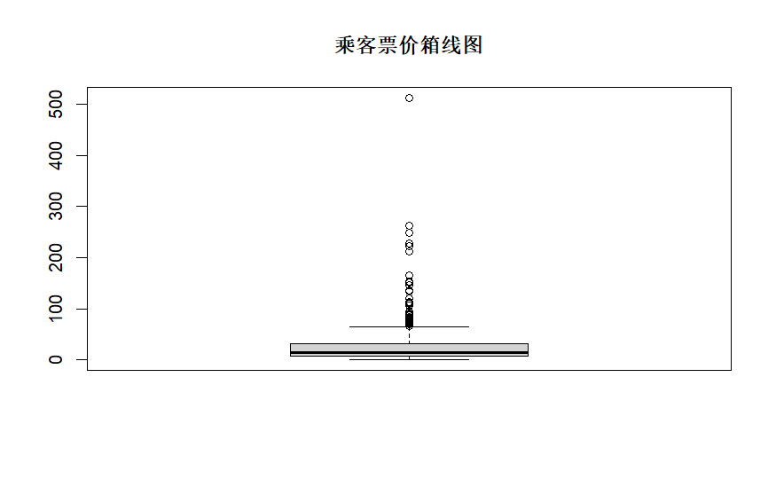

```r
# 使用箱线图等可视化工具分析异常值
boxplot(titanic_data$Fare, main = "乘客票价箱线图")
```

四、数据预处理

1.缺失值处理

根据原始数据分析的结果可知，Age属性有177个缺失值，Embarked属性有2个缺失值，Cabin属性有687个缺失值。对于这三种缺失值，分别采用不同的处理方式。

修补Embarked数据 对于Embarked这种缺失值极少的，适合用该属性的取值最多的值来填补缺失值。

```r
# 查询 Embarked 属性的各值的数量统计
embarked_counts <- table(titanic_data$Embarked)

# 找到数量最多的 Embarked 取值
most_common_embarked <- names(which.max(embarked_counts))

# 将 Embarked 列中的空字符串替换为最多的取值
titanic_data$Embarked[titanic_data$Embarked == ""] <- most_common_embarked
```

修补Cabin数据 对于Cabbin这种缺失值占比很大的，并且不为数字类型的，可以将缺失值作为新的一类填补进去。由于Cabin是表示客舱编号，客舱的位置很大可能影响人的生存情况，根据数据实际的情况来看，Cabin为空可能代表没有客舱可坐，所以将空值单独作为新值是有必要且有实际意义的。

```r
# 将 Cabin 属性中的缺失值替换为 "NC"
titanic_data$Cabin[titanic_data$Cabin == ""] <- "NC"
```

修补Age数据 对于Age这种缺失值占比较大的，且为数字类型的，可以从特殊角度考虑数据填补的方法。注意到在Name属性一栏中有乘客身份相关的信息，例如Mr、Miss、Mrs等，考虑到乘客身份很有可能跟年龄有关系，所以先统计一下各种称呼的人数：

```r
# 提取姓名中的称谓作为新的特征
titanic_data$Title <- gsub('.*,\\s(\\w+)\\..*', '\\1', titanic_data$Name)

# 统计各种称呼的人数
title_counts <- table(titanic_data$Title)

# 输出结果
print(title_counts)
```

```
                                                    Capt                                                      Col
                                                       1                                                        2
                                                     Don                                                       Dr
                                                       1                                                        7
                                                Jonkheer                                                     Lady
                                                       1                                                        1
                                                   Major                                                   Master
                                                       2                                                       40
                                                    Miss                                                     Mlle
                                                     182                                                        2
                                                     Mme                                                       Mr
                                                       1                                                      517
                                                     Mrs                                                       Ms
                                                     125                                                        1
                                                     Rev Rothes, the Countess. of (Lucy Noel Martha Dyer-Edwards)
                                                       6                                                        1
                                                     Sir
                                                       1
```

可以发现最主要的身份包括Mr、Miss、Mrs、Master，其他身份都是少数，所以将乘客身份信息分为五类，每种身份分别计算年龄的平均值。

由于要计算平均值，所以先查找年龄数据是否有异常值，先做异常值处理。年龄的异常值需要根据实际情况来考虑，而不是根据数据分布情况，只需要考虑数据是否在正常年龄范围内（0~120岁）即可。根据以下代码：

```r
# 查找年龄中的异常值
age_outliers <- titanic_data$Age < 0 | titanic_data$Age > 120

# 输出异常值
print(titanic_data[age_outliers, c("PassengerId", "Age")])
```

[output not shown]

[output cut: 167 more lines]

可见没有异常值。 接下来分别计算不同身份的年龄平均数：

```r
# 创建新的身份类别列
titanic_data$TitleCategory <- ifelse(titanic_data$Title %in% c("Mr", "Miss", "Mrs", "Master"), titanic_data$Title, "Other")

# 计算各个身份类别的年龄平均值（排除空值）
average_age_by_title <- tapply(titanic_data$Age[!is.na(titanic_data$Age)], titanic_data$TitleCategory[!is.na(titanic_data$Age)], mean)

# 输出结果
print(average_age_by_title)
```

```
   Master      Miss        Mr       Mrs     Other
 4.574167 21.773973 32.368090 35.898148 42.384615
```

四舍五入填入空缺的身份信息类：

```r
# 根据身份信息填充空缺年龄数据
for (title_category in names(average_age_by_title)) {
  missing_age_indices <- which(is.na(titanic_data$Age) & titanic_data$TitleCategory == title_category)
  average_age_rounded <- round(average_age_by_title[[title_category]])
  titanic_data$Age[missing_age_indices] <- average_age_rounded
}

titanic_data$AgeGroup <- cut(titanic_data$Age, breaks = c(-Inf, 18, 30, 50, Inf), labels = c("0-18", "19-30", "31-50", "51+"))
```

2.异常值处理 年龄异常值前面已经寻找过，另一个可能出现异常值的属性为票价，根据原始数据分析中的票价箱线图中可以看出，有值明显偏离数据集中区域，下面进行分析：

```r
# 票价异常值处理
# 找出票价超过500的行
high_fare_rows <- which(titanic_data$Fare > 500)

# 输出找到的行
print(titanic_data[high_fare_rows, ])
```

|  | PassengerId | Survived | Pclass | Name | Sex | Age | SibSp | Parch | Ticket | Fare | Cabin | Embarked | AgeGroup | Title | TitleCategory |
| --- | --- | --- | --- | --- | --- | --- | --- | --- | --- | --- | --- | --- | --- | --- | --- |
| 259 | 259 | 1 | 1 | Ward, Miss. Anna | female | 35 | 0 | 0 | PC 17755 | 512.3292 | NC | C | 31-50 | Miss | Miss |
| 680 | 680 | 1 | 1 | Cardeza, Mr. Thomas Drake Martinez | male | 36 | 0 | 1 | PC 17755 | 512.3292 | B51 B53 B55 | C | 31-50 | Mr | Mr |
| 738 | 738 | 1 | 1 | Lesurer, Mr. Gustave J | male | 35 | 0 | 0 | PC 17755 | 512.3292 | B101 | C | 31-50 | Mr | Mr |

发现票价超过500的票价都为512.3292，且Pclass都为1，故该票价为异常值的可能性很小，故不做处理。

3.数据去重

```r
# 检测是否有重复行
has_duplicates <- any(duplicated(titanic_data))

# 输出结果
print(has_duplicates)
```

```
[1] FALSE
```

输出结果为FALSE，说明没有重复数据。

4.数据数值化及其他处理 由于数据分析通常需要对数值进行研究，所以有必要将一些字符型数据转变成数值型数据。由于Ticket数据类别过多，且实际情况中与存活率关系不大，可以考虑不处理这个属性。

sex数据数值化（男性为1，女性为0）

```r
# 将 "male" 编码为 1，"female" 编码为 0
titanic_data$Gender <- ifelse(titanic_data$Sex == "male", 1, 0)
```

Embarked 数据数值化 两种方法： 方法一：映射整数

```r
# 使用 label encoding 将 Embarked 列映射为整数
titanic_data$Embarked_Code <- as.integer(factor(titanic_data$Embarked))
```

方法二：独热编码

```r
# 对 Embarked 列进行独热编码
embarked_one_hot <- model.matrix(~ Embarked - 1, data = titanic_data)
```

TitleCategory 数据数值化 两种方法： 方法一：映射整数

```r
# 将 TitleCategory 列进行 Label Encoding
titanic_data$Title_Code <- as.integer(factor(titanic_data$TitleCategory))
```

方法二：独热编码

```r
# 对 TitleCategory 列进行独热编码
title_one_hot <- model.matrix(~ TitleCategory - 1, data = titanic_data)
```

Cabin 数据数值化

```r
# 将 Cabin 列进行 Label Encoding
titanic_data$Cabin_Code <- as.integer(factor(titanic_data$Cabin))
```

```r
# 将编码结果添加到原始数据集
titanic_data <- cbind(titanic_data, embarked_one_hot, title_one_hot)
```

```r
library(caret)

# 设置随机种子以确保结果可重复
# set.seed(1)

# 划分数据集，80% 用于训练，20% 用于测试
index <- createDataPartition(titanic_data$Survived, p = 0.8, list = FALSE)
train_data <- titanic_data[index, ]
test_data <- titanic_data[-index, ]

print(paste("训练集观测数：", nrow(train_data)))
```

```
[1] "训练集观测数： 713"
```

```r
print(paste("测试集观测数：", nrow(test_data)))
```

```
[1] "测试集观测数： 178"
```

方法一(映射整数)测试：

```r
# 导入逻辑回归库
library(glmnet)

glm_model1 <- glm(Survived ~ Age + Gender + Pclass + SibSp + Parch + Fare + Cabin_Code + Embarked_Code + Title_Code,
                 family = binomial,
                 data = train_data)
summary(glm_model1)
```

```
Call:
glm(formula = Survived ~ Age + Gender + Pclass + SibSp + Parch +
    Fare + Cabin_Code + Embarked_Code + Title_Code, family = binomial,
    data = train_data)

Coefficients:
               Estimate Std. Error z value Pr(>|z|)
(Intercept)    5.591442   0.784843   7.124 1.05e-12 ***
Age           -0.037618   0.010271  -3.663  0.00025 ***
Gender        -2.683302   0.220945 -12.145  < 2e-16 ***
Pclass        -0.975358   0.182840  -5.334 9.58e-08 ***
SibSp         -0.283497   0.117366  -2.416  0.01571 *
Parch         -0.105002   0.128970  -0.814  0.41556
Fare           0.002744   0.002699   1.017  0.30924
Cabin_Code    -0.002575   0.003720  -0.692  0.48879
Embarked_Code -0.108544   0.131451  -0.826  0.40895
Title_Code    -0.159885   0.146378  -1.092  0.27471
---
Signif. codes:  0 ‘***’ 0.001 ‘**’ 0.01 ‘*’ 0.05 ‘.’ 0.1 ‘ ’ 1

(Dispersion parameter for binomial family taken to be 1)

    Null deviance: 939.87  on 712  degrees of freedom
Residual deviance: 626.57  on 703  degrees of freedom
AIC: 646.57

Number of Fisher Scoring iterations: 5
```

```r
# 计算准确率
predictions1 <- predict(glm_model1, newdata = test_data, type = "response")
predicted_classes <- ifelse(predictions1 > 0.5, 1, 0)
accuracy <- sum(predicted_classes == test_data$Survived) / length(test_data$Survived)
print(paste("模型1准确率:", round(accuracy, 4)))
```

```
[1] "模型1准确率: 0.8034"
```

多次实验后发现Fare、Cabin_Code、Title_Code、Parch、Embarked_Code的p值始终较大。所以： 去除Fare、Cabin_Code、Title_Code、Parch、Embarked_Code：

```r
glm_model2 <- glm(Survived ~ Age + Gender + Pclass + SibSp, family = binomial, data = train_data)
summary(glm_model2)
```

```
Call:
glm(formula = Survived ~ Age + Gender + Pclass + SibSp, family = binomial,
    data = train_data)

Coefficients:
             Estimate Std. Error z value Pr(>|z|)
(Intercept)  5.140977   0.533403   9.638  < 2e-16 ***
Age         -0.043621   0.008705  -5.011 5.42e-07 ***
Gender      -2.660656   0.213760 -12.447  < 2e-16 ***
Pclass      -1.161059   0.135514  -8.568  < 2e-16 ***
SibSp       -0.289270   0.112265  -2.577  0.00998 **
---
Signif. codes:  0 ‘***’ 0.001 ‘**’ 0.01 ‘*’ 0.05 ‘.’ 0.1 ‘ ’ 1

(Dispersion parameter for binomial family taken to be 1)

    Null deviance: 939.87  on 712  degrees of freedom
Residual deviance: 631.79  on 708  degrees of freedom
AIC: 641.79

Number of Fisher Scoring iterations: 5
```

```r
# 计算准确率
predictions2 <- predict(glm_model2, newdata = test_data, type = "response")
predicted_classes <- ifelse(predictions2 > 0.5, 1, 0)
accuracy <- sum(predicted_classes == test_data$Survived) / length(test_data$Survived)
print(paste("模型2准确率:", round(accuracy, 4)))
```

```
[1] "模型2准确率: 0.809"
```

方法二测试： 考虑到部分属性之间存在共线性问题，会导致p值输出异常，共线性分析如下：

```r
glm_model3 <- glm(Survived ~ Age + Gender + Pclass + SibSp + Parch + Fare + Cabin_Code + EmbarkedC + EmbarkedQ + TitleCategoryMaster + TitleCategoryMiss + TitleCategoryMr + TitleCategoryMrs, family = binomial, data = train_data)
library(car)
vif(glm_model3)
```

```
                Age              Gender              Pclass               SibSp               Parch                Fare          Cabin_Code
       2.058544e+00        8.666740e+06        2.537471e+00        1.620927e+00        1.415735e+00        1.583421e+00        1.875172e+00
          EmbarkedC           EmbarkedQ TitleCategoryMaster   TitleCategoryMiss     TitleCategoryMr    TitleCategoryMrs
       1.124790e+00        1.181667e+00        4.217568e+00        6.838368e+06        9.924349e+00        4.742374e+06
```

```r
glm_model4 <- glm(Survived ~ Age + Gender + Pclass + SibSp + Parch + Fare + Cabin_Code + EmbarkedC + EmbarkedQ + TitleCategoryMaster , family = binomial, data = train_data)
summary(glm_model4)
```

```
Call:
glm(formula = Survived ~ Age + Gender + Pclass + SibSp + Parch +
    Fare + Cabin_Code + EmbarkedC + EmbarkedQ + TitleCategoryMaster,
    family = binomial, data = train_data)

Coefficients:
                     Estimate Std. Error z value Pr(>|z|)
(Intercept)          4.352870   0.706758   6.159 7.32e-10 ***
Age                 -0.018235   0.009604  -1.899  0.05762 .
Gender              -3.264049   0.256606 -12.720  < 2e-16 ***
Pclass              -0.883297   0.195109  -4.527 5.98e-06 ***
SibSp               -0.501754   0.133969  -3.745  0.00018 ***
Parch               -0.310127   0.140732  -2.204  0.02755 *
Fare                 0.004201   0.002919   1.439  0.15011
Cabin_Code          -0.002664   0.003847  -0.692  0.48868
EmbarkedC            0.184168   0.282977   0.651  0.51516
EmbarkedQ           -0.023846   0.372750  -0.064  0.94899
TitleCategoryMaster  3.541759   0.593361   5.969 2.39e-09 ***
---
Signif. codes:  0 ‘***’ 0.001 ‘**’ 0.01 ‘*’ 0.05 ‘.’ 0.1 ‘ ’ 1

(Dispersion parameter for binomial family taken to be 1)

    Null deviance: 939.87  on 712  degrees of freedom
Residual deviance: 587.02  on 702  degrees of freedom
AIC: 609.02

Number of Fisher Scoring iterations: 5
```

```r
predictions4 <- predict(glm_model4, newdata = test_data, type = "response")
predicted_classes <- ifelse(predictions4 > 0.5, 1, 0)
accuracy <- sum(predicted_classes == test_data$Survived) / length(test_data$Survived)
print(paste("模型4准确率:", round(accuracy, 4)))
```

```
[1] "模型4准确率: 0.8202"
```

删除Fare、Cabin_Code、EmbarkedQ、EmbarkedC、Parch:

```r
glm_model5 <- glm(Survived ~ Age + Gender + Pclass + SibSp + TitleCategoryMaster , family = binomial, data = train_data)
summary(glm_model5)
```

```
Call:
glm(formula = Survived ~ Age + Gender + Pclass + SibSp + TitleCategoryMaster,
    family = binomial, data = train_data)

Coefficients:
                     Estimate Std. Error z value Pr(>|z|)
(Intercept)          4.581495   0.551797   8.303  < 2e-16 ***
Age                 -0.020299   0.009514  -2.134   0.0329 *
Gender              -3.116985   0.238153 -13.088  < 2e-16 ***
Pclass              -1.124081   0.141967  -7.918 2.42e-15 ***
SibSp               -0.526760   0.127965  -4.116 3.85e-05 ***
TitleCategoryMaster  3.270951   0.582513   5.615 1.96e-08 ***
---
Signif. codes:  0 ‘***’ 0.001 ‘**’ 0.01 ‘*’ 0.05 ‘.’ 0.1 ‘ ’ 1

(Dispersion parameter for binomial family taken to be 1)

    Null deviance: 939.87  on 712  degrees of freedom
Residual deviance: 595.78  on 707  degrees of freedom
AIC: 607.78

Number of Fisher Scoring iterations: 5
```

```r
predictions5 <- predict(glm_model5, newdata = test_data, type = "response")
predicted_classes <- ifelse(predictions5 > 0.5, 1, 0)
accuracy <- sum(predicted_classes == test_data$Survived) / length(test_data$Survived)
print(paste("模型5准确率:", round(accuracy, 4)))
```

```
[1] "模型5准确率: 0.8202"
```

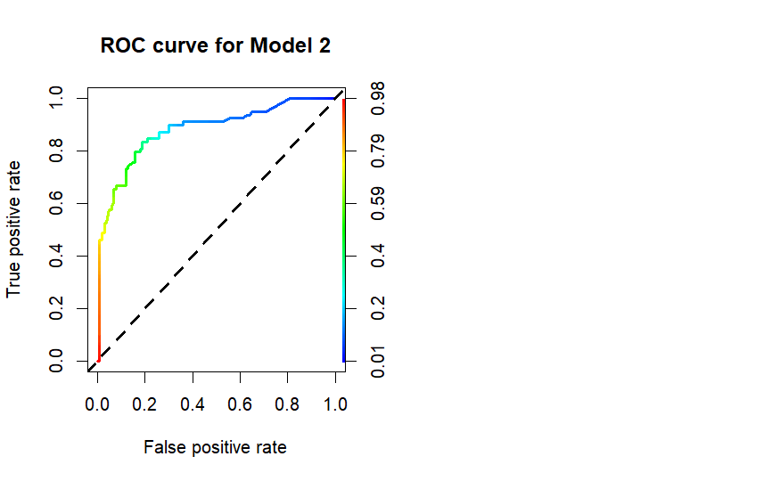

```r
# Assuming you have fit2 and fit5
par(mfrow=c(1,2))
library(ROCR)

plot_roc <- function(predictions, actuals, main_title) {
  pred <- prediction(predictions, actuals)
  auc <- performance(pred, "auc")@y.values
  plot(performance(pred, "tpr", "fpr"), colorize = TRUE, lwd = 3, main = main_title)
  abline(a = 0, b = 1, lty = 2, lwd = 3, col = "black")
  return(auc)
}

# Assuming predictions2 and predictions5 are the predicted probabilities for models 2 and 5
actuals <- test_data$Survived

# Plot ROC curve and calculate AUC for Model 2
auc2 <- plot_roc(predictions2, actuals, "ROC curve for Model 2")

# Plot ROC curve and calculate AUC for Model 5
auc5 <- plot_roc(predictions5, actuals, "ROC curve for Model 5")
```

[output not shown]

```r
# Print AUC values
cat("AUC for Model 2:", auc2[[1]], "\n")
```

```
AUC for Model 2: 0.876859
```

```r
cat("AUC for Model 5:", auc5[[1]], "\n")
```

```
AUC for Model 5: 0.8900641
```

```r
# 混淆矩阵函数
conf_matrix <- function(predictions, true_labels, threshold) {
  predicted_labels <- ifelse(predictions > threshold, 1, 0)
  confusion_matrix <- table(predicted_labels, true_labels)
  return(confusion_matrix)
}

# 计算准确率
accuracy <- function(conf_matrix) {
  sum(diag(conf_matrix)) / sum(conf_matrix)
}

# 计算灵敏度
sensitivity <- function(conf_matrix) {
  conf_matrix[2, 2] / sum(conf_matrix[2, ])
}

# 计算特异度
specificity <- function(conf_matrix) {
  conf_matrix[1, 1] / sum(conf_matrix[1, ])
}

# 计算精准率
precision <- function(conf_matrix) {
  conf_matrix[2, 2] / sum(conf_matrix[, 2])
}

# 计算F1值
f1_score <- function(conf_matrix) {
  2 * precision(conf_matrix) * sensitivity(conf_matrix) / (precision(conf_matrix) + sensitivity(conf_matrix))
}

# 模型2的性能指标
threshold2 <- 0.5  # 可根据需要调整阈值
conf_matrix2 <- conf_matrix(predictions2, test_data$Survived, threshold2)

cat("Model 2:\n")
cat("准确率 (Accuracy):", accuracy(conf_matrix2), "\n")
cat("灵敏度 (Sensitivity):", sensitivity(conf_matrix2), "\n")
cat("特异度 (Specificity):", specificity(conf_matrix2), "\n")
cat("精准率 (Precision):", precision(conf_matrix2), "\n")
cat("F1值 (F1 Score):", f1_score(conf_matrix2), "\n")

# 模型5的性能指标
threshold5 <- 0.5  # 可根据需要调整阈值
conf_matrix5 <- conf_matrix(predictions5, test_data$Survived, threshold5)

cat("\nModel 5:\n")
cat("准确率 (Accuracy):", accuracy(conf_matrix5), "\n")
cat("灵敏度 (Sensitivity):", sensitivity(conf_matrix5), "\n")
cat("特异度 (Specificity):", specificity(conf_matrix5), "\n")
cat("精准率 (Precision):", precision(conf_matrix5), "\n")
cat("F1值 (F1 Score):", f1_score(conf_matrix5), "\n")
```

[output not shown]

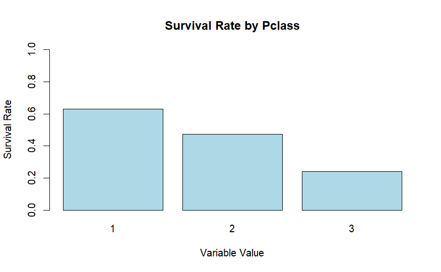

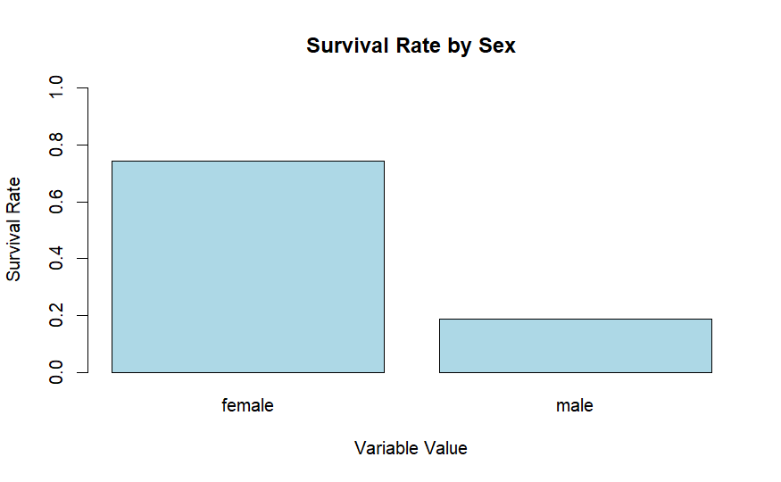

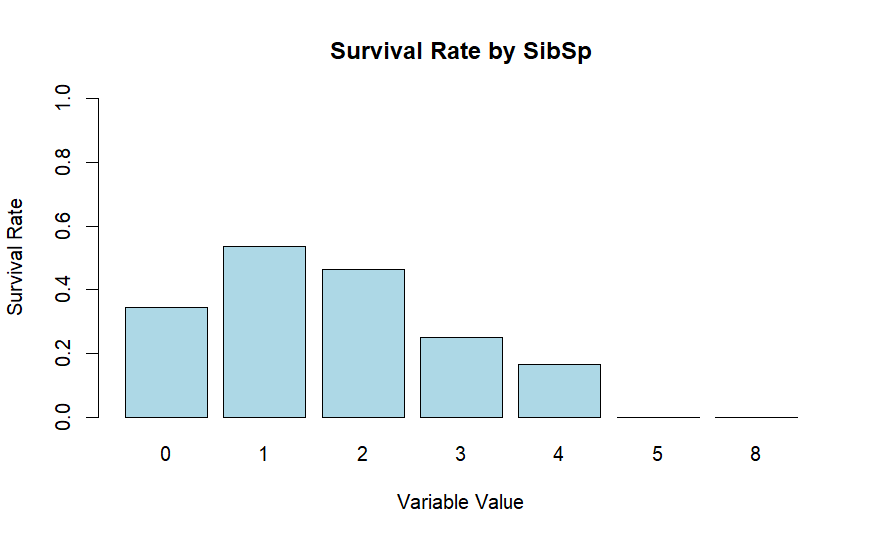

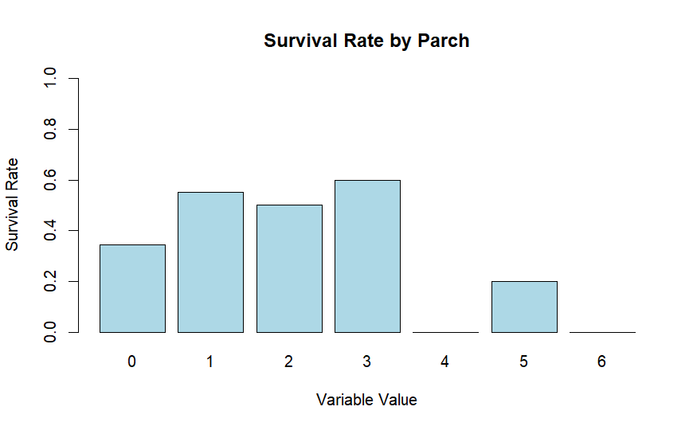

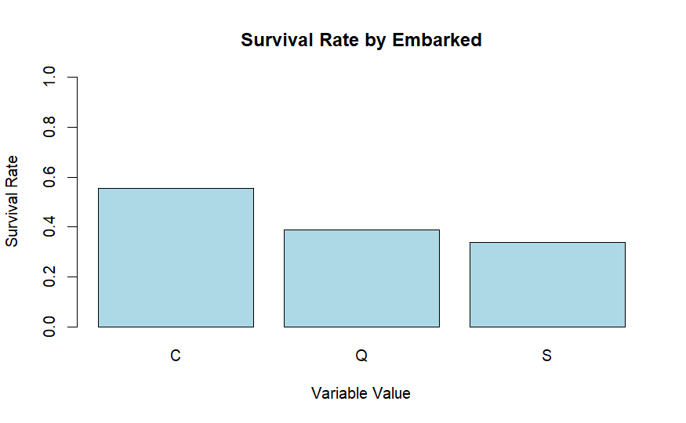

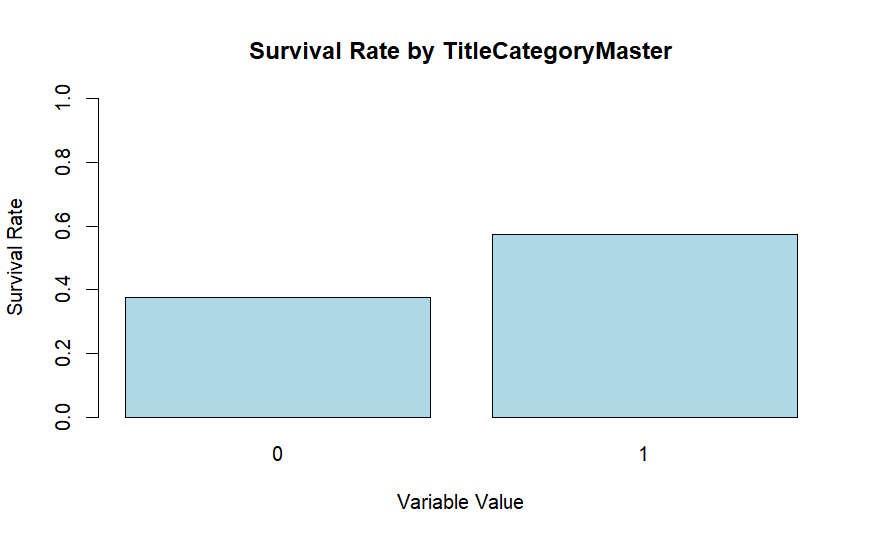

```r
# 计算存活率
calculate_survival_rate <- function(data, variable) {
  survival_table <- table(data[[variable]], data$Survived)
  survival_rate <- survival_table[, 2] / rowSums(survival_table)
  return(data.frame(variable_value = names(survival_rate), survival_rate))
}

# 创建柱状图
plot_survival_rate <- function(survival_data, title) {
  barplot(survival_data$survival_rate, names.arg = survival_data$variable_value,
          ylim = c(0, 1), main = title,
          xlab = "Variable Value", ylab = "Survival Rate", col = "lightblue",
          beside = TRUE)
}

# 计算并可视化所有属性与存活率的关系
variables_of_interest <- c("Pclass", "Sex", "SibSp", "Parch", "Embarked", "TitleCategoryMaster", "AgeGroup")

# par(mfrow=c(3, 2))  # 设置布局为3行2列的图表

for (variable in variables_of_interest) {
  survival_data <- calculate_survival_rate(titanic_data, variable)
  plot_survival_rate(survival_data, paste("Survival Rate by", variable))
}
```

[figure not shown]

```r
# 恢复默认图表布局
par(mfrow=c(1, 1))
```

经过如上图示并综合模型分析结果可以发现，生存率和性别、票级、兄弟姐妹/配偶数关系较大，女性、票级越高、有一到两个同行者存活率更高，同时也与年龄有一定关系，年龄更小的相对存活率高些，同时有一个特殊的发现，即头衔为Master的人存活率普遍高于其他人。